# Survival_Analysis_week2

202430527 leetaenyoung

2025-09-12

## 1 Week 2 assignment

### 1.1 Question

- For the vets.dat data set described in the presentation:
  - **(a)** Obtain **KM plots** for the two categories of the variable *cell type 1(1 = large, 0 = other)*. Comment on how the **two curves compare** with each other. Carry out the **log-rank**, and draw **conclusions** from the test(s).
  - **(b)** Obtain **KM plots** for the four categories of *cell type-large, adeno, small and squamous*. Note that you will need to *recode the data* to define a single variable which numerically distinguishes the four categories *(e.g. 1=large, 2=adeno, etc.)*. As in part a, **compare the four KM curves**. Also carry out the **log-rank** for the equality of the four curves and draw **conclusions**.

#### 1.1.1 Data import

```r
vets <- read.table("vets.txt", header = TRUE)
```

#### 1.1.2 Data exploration

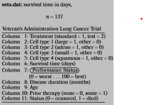

Data explanation

```r
# include null?
sum(is.na(vets))
```

```
## [1] 0
```

```r
# how it looks like?
head(vets, 3)
```

|  | Trt | CT1 | CT2 | CT3 | CT4 | time | PS | DD | age | PT | status |
| --- | --- | --- | --- | --- | --- | --- | --- | --- | --- | --- | --- |
| 1 | 1 | 0 | 0 | 0 | 1 | 72 | 60 | 7 | 69 | 0 | 1 |
| 2 | 1 | 0 | 0 | 0 | 1 | 411 | 70 | 5 | 64 | 10 | 1 |
| 3 | 1 | 0 | 0 | 0 | 1 | 228 | 60 | 3 | 38 | 0 | 1 |

```r
tail(vets, 3)
```

|  | Trt | CT1 | CT2 | CT3 | CT4 | time | PS | DD | age | PT | status |
| --- | --- | --- | --- | --- | --- | --- | --- | --- | --- | --- | --- |
| 135 | 2 | 1 | 0 | 0 | 0 | 231 | 70 | 18 | 67 | 10 | 1 |
| 136 | 2 | 1 | 0 | 0 | 0 | 378 | 80 | 4 | 65 | 0 | 1 |
| 137 | 2 | 1 | 0 | 0 | 0 | 49 | 30 | 3 | 37 | 0 | 1 |

```r
# unique variable?
sapply(vets, function(x) length(unique(x)))
```

```
##    Trt    CT1    CT2    CT3    CT4   time     PS     DD    age     PT status
##      2      2      2      2      2    101     12     28     40      2      2
```

```r
# what value?
sapply(vets[,1:5], function(x) unique(x))
```

```
##      Trt CT1 CT2 CT3 CT4
## [1,]   1   0   0   0   1
## [2,]   2   1   1   1   0
```

```r
sapply(vets[,10:ncol(vets)], function(x) unique(x))
```

```
##      PT status
## [1,]  0      1
## [2,] 10      0
```

```r
# summary
summary(vets[,6:9])
```

```
##       time             PS              DD              age
##  Min.   :  1.0   Min.   :10.00   Min.   : 1.000   Min.   :34.00
##  1st Qu.: 25.0   1st Qu.:40.00   1st Qu.: 3.000   1st Qu.:51.00
##  Median : 80.0   Median :60.00   Median : 5.000   Median :62.00
##  Mean   :121.6   Mean   :58.57   Mean   : 8.774   Mean   :58.31
##  3rd Qu.:144.0   3rd Qu.:75.00   3rd Qu.:11.000   3rd Qu.:66.00
##  Max.   :999.0   Max.   :99.00   Max.   :87.000   Max.   :81.00
```

#### 1.1.3 pre-processing

```r
# integrate 4 level CT into one factor column(cell)
vets$cell <- ifelse(vets$CT1 == 1, "large",
              ifelse(vets$CT2 == 1, "adeno",
              ifelse(vets$CT3 == 1, "small",
                     "squamous")))
vets$cell <- factor(vets$cell,
                     levels = c("large", "adeno", "small", "squamous"))
```

### 1.2 (a)

#### 1.2.1 Data seperation (large <-> other)

```r
vets$large_vs_other <- ifelse(vets$cell == "large", "large", "other")
```

#### 1.2.2 Obtain KM plots

```r
library(survival)
```

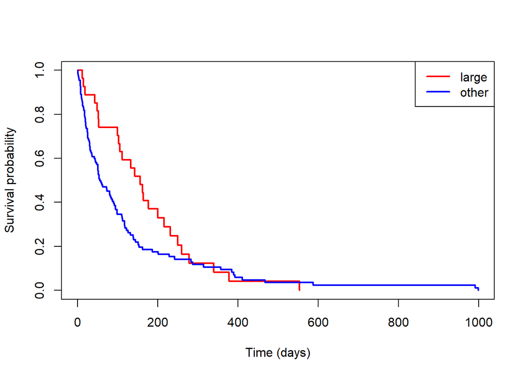

```r
fit <- survfit(Surv(time, status) ~ large_vs_other, data = vets)

plot(fit, col = c("red", "blue"), lwd = 2,
     xlab = "Time (days)", ylab = "Survival probability")
legend("topright", legend = levels(factor(vets$large_vs_other)),
       col = c("red","blue"), lwd = 2)
```

```r
survdiff(Surv(time, status) ~ large_vs_other, data = vets)
```

```
## Call:
## survdiff(formula = Surv(time, status) ~ large_vs_other, data = vets)
##
##                        N Observed Expected (O-E)^2/E (O-E)^2/V
## large_vs_other=large  27       26     34.5     2.116      3.02
## large_vs_other=other 110      102     93.5     0.782      3.02
##
##  Chisq= 3  on 1 degrees of freedom, p= 0.08
```

#### 1.2.3 Conclusion

According to the *log-rank test (χ² = 3, df = 1, p = 0.08)*, there is *no significant difference* in survival between the two groups.

### 1.3 (b)

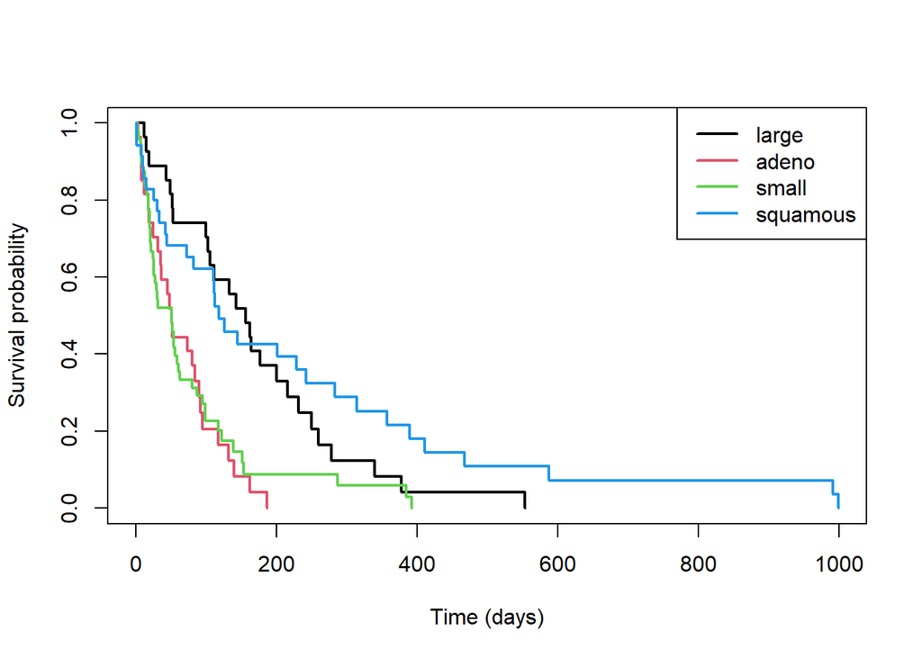

```r
fit <- survfit(Surv(time, status) ~ cell, data = vets)

plot(fit, col = 1:4, lwd = 2,
     xlab = "Time (days)", ylab = "Survival probability")
legend("topright", legend = levels(vets$cell),
       col = 1:4, lwd = 2)
```

```r
survdiff(Surv(time, status) ~ cell, data = vets)
```

```
## Call:
## survdiff(formula = Surv(time, status) ~ cell, data = vets)
##
##                N Observed Expected (O-E)^2/E (O-E)^2/V
## cell=large    27       26     34.5      2.12      3.02
## cell=adeno    27       26     15.7      6.77      8.19
## cell=small    48       45     30.1      7.37     10.20
## cell=squamous 35       31     47.7      5.82     10.53
##
##  Chisq= 25.4  on 3 degrees of freedom, p= 1e-05
```

#### 1.3.1 Conclusion

According to the *log-rank test (χ² = 25.4, df = 3, p < 0.001)*, there is a *highly significant difference* in survival among the four cell types.

[figure not shown]